# statistics

```python
import pandas as pd
import matplotlib.pyplot as plt
import matplotlib.dates as mdates
from matplotlib.gridspec import GridSpec
%matplotlib inline

import datetime
import geopandas as gpd

import numpy as np
import seaborn as sns
```

```python
import warnings
warnings.filterwarnings("ignore")

pd.set_option("display.float_format",lambda x: "%.2f" % x)
```

```python
#importing data using pandas

df_covid = pd.read_csv("covidde/covid_de.csv")
df_dmo = pd.read_csv("covidde/demographics_de.csv")


#reading .shp (shapeFile) file using geopandas. geopandas extends the datatypes used by pandas
df_mp = gpd.read_file("covidde/de_state.shp")
#df_mp_country = gpd.read_file("covidde/de_county.shp")
```

```python
df_covid
```

|  | state | county | age_group | gender | date | cases | deaths | recovered |
| --- | --- | --- | --- | --- | --- | --- | --- | --- |
| 0 | Baden-Wuerttemberg | LK Alb-Donau-Kreis | 00-04 | F | 2020-03-27 | 1 | 0 | 1 |
| 1 | Baden-Wuerttemberg | LK Alb-Donau-Kreis | 00-04 | F | 2020-03-28 | 1 | 0 | 1 |
| 2 | Baden-Wuerttemberg | LK Alb-Donau-Kreis | 00-04 | F | 2020-04-03 | 1 | 0 | 1 |
| 3 | Baden-Wuerttemberg | LK Alb-Donau-Kreis | 00-04 | F | 2020-10-18 | 1 | 0 | 1 |
| 4 | Baden-Wuerttemberg | LK Alb-Donau-Kreis | 00-04 | F | 2020-10-22 | 1 | 0 | 1 |
| ... | ... | ... | ... | ... | ... | ... | ... | ... |
| 416309 | Thueringen | SK Weimar | 80-99 | M | 2020-12-26 | 4 | 1 | 0 |
| 416310 | Thueringen | SK Weimar | 80-99 | M | 2020-12-28 | 1 | 0 | 0 |
| 416311 | Thueringen | SK Weimar | 80-99 | M | 2020-12-30 | 2 | 0 | 0 |
| 416312 | Thueringen | SK Weimar | 80-99 | M | 2020-12-31 | 1 | 0 | 0 |
| 416313 | Thueringen | SK Weimar | NaN | F | 2020-12-31 | 1 | 0 | 0 |

416314 rows × 8 columns

```python
#changing the name of state column value

df_covid["state"] = df_covid["state"].replace("Baden-Wuerttemberg", "Baden-Württemberg")
df_covid["state"] = df_covid["state"].replace("Thueringen", "Thüringen")
```

```python
df_covid
```

|  | state | county | age_group | gender | date | cases | deaths | recovered |
| --- | --- | --- | --- | --- | --- | --- | --- | --- |
| 0 | Baden-Württemberg | LK Alb-Donau-Kreis | 00-04 | F | 2020-03-27 | 1 | 0 | 1 |
| 1 | Baden-Württemberg | LK Alb-Donau-Kreis | 00-04 | F | 2020-03-28 | 1 | 0 | 1 |
| 2 | Baden-Württemberg | LK Alb-Donau-Kreis | 00-04 | F | 2020-04-03 | 1 | 0 | 1 |
| 3 | Baden-Württemberg | LK Alb-Donau-Kreis | 00-04 | F | 2020-10-18 | 1 | 0 | 1 |
| 4 | Baden-Württemberg | LK Alb-Donau-Kreis | 00-04 | F | 2020-10-22 | 1 | 0 | 1 |
| ... | ... | ... | ... | ... | ... | ... | ... | ... |
| 416309 | Thüringen | SK Weimar | 80-99 | M | 2020-12-26 | 4 | 1 | 0 |
| 416310 | Thüringen | SK Weimar | 80-99 | M | 2020-12-28 | 1 | 0 | 0 |
| 416311 | Thüringen | SK Weimar | 80-99 | M | 2020-12-30 | 2 | 0 | 0 |
| 416312 | Thüringen | SK Weimar | 80-99 | M | 2020-12-31 | 1 | 0 | 0 |
| 416313 | Thüringen | SK Weimar | NaN | F | 2020-12-31 | 1 | 0 | 0 |

416314 rows × 8 columns

```python
#formatting date value
df_covid["date"] = pd.to_datetime(df_covid["date"])
```

```python
#changing the name of state column value

df_dmo["state"] = df_dmo["state"].replace("Baden-Wuerttemberg", "Baden-Württemberg")
df_dmo["state"] = df_dmo["state"].replace("Thueringen", "Thüringen")
```

```python
#changing the value of gender column of df_dmp dataframe

df_dmo["gender"] = np.where(df_dmo["gender"] == "female", "F", "M" )
```

```python
df_dmo
```

|  | state | gender | age_group | population |
| --- | --- | --- | --- | --- |
| 0 | Baden-Württemberg | F | 00-04 | 261674 |
| 1 | Baden-Württemberg | F | 05-14 | 490822 |
| 2 | Baden-Württemberg | F | 15-34 | 1293488 |
| 3 | Baden-Württemberg | F | 35-59 | 1919649 |
| 4 | Baden-Württemberg | F | 60-79 | 1182736 |
| ... | ... | ... | ... | ... |
| 187 | Thüringen | M | 05-14 | 92545 |
| 188 | Thüringen | M | 15-34 | 214553 |
| 189 | Thüringen | M | 35-59 | 384822 |
| 190 | Thüringen | M | 60-79 | 264189 |
| 191 | Thüringen | M | 80-99 | 57340 |

192 rows × 4 columns

```python
#finding 'NA' values and displaying them"

df_covid[(df_covid["gender"].isnull()) | (df_covid["age_group"].isnull())]
```

|  | state | county | age_group | gender | date | cases | deaths | recovered |
| --- | --- | --- | --- | --- | --- | --- | --- | --- |
| 200 | Baden-Württemberg | LK Alb-Donau-Kreis | 05-14 | NaN | 2020-10-30 | 1 | 0 | 1 |
| 201 | Baden-Württemberg | LK Alb-Donau-Kreis | 05-14 | NaN | 2020-11-19 | 1 | 0 | 1 |
| 517 | Baden-Württemberg | LK Alb-Donau-Kreis | 15-34 | NaN | 2020-10-28 | 1 | 0 | 1 |
| 518 | Baden-Württemberg | LK Alb-Donau-Kreis | 15-34 | NaN | 2020-10-30 | 2 | 0 | 2 |
| 519 | Baden-Württemberg | LK Alb-Donau-Kreis | 15-34 | NaN | 2020-11-01 | 1 | 0 | 1 |
| ... | ... | ... | ... | ... | ... | ... | ... | ... |
| 415484 | Thüringen | SK Jena | NaN | F | 2020-12-29 | 1 | 0 | 0 |
| 415485 | Thüringen | SK Jena | NaN | M | 2020-12-28 | 1 | 0 | 0 |
| 415486 | Thüringen | SK Jena | NaN | M | 2020-12-29 | 1 | 0 | 0 |
| 415487 | Thüringen | SK Jena | NaN | M | 2020-12-30 | 2 | 0 | 0 |
| 416313 | Thüringen | SK Weimar | NaN | F | 2020-12-31 | 1 | 0 | 0 |

11402 rows × 8 columns

```python
df_dmo[(df_dmo["gender"].isnull()) | (df_dmo["age_group"].isnull())]
```

|  | state | gender | age_group | population |
| --- | --- | --- | --- | --- |

# This data set has no "NaN" values

```python
#getting the sum of the 'NA' values

df_covid[(df_covid["gender"].isnull()) | (df_covid["age_group"].isnull())].sum()
```

```
state        Baden-WürttembergBaden-WürttembergBaden-Württe...
county       LK Alb-Donau-KreisLK Alb-Donau-KreisLK Alb-Don...
cases                                                    17160
deaths                                                      65
recovered                                                12189
dtype: object
```

```python
#filling age_group "NA" values with most frequent values

group = df_covid.age_group.value_counts().idxmax()
df_covid.age_group.fillna(group, inplace = True)
```

```python
#filling missing values of gender column (half with 'M' and other half with 'F')

gender = df_covid.gender.isna()
gen = df_covid.gender.loc[gender].sample(frac = 0.5).index  #generating random rows
df_covid.loc[gen, 'gender'] = 'M'
df_covid.gender.fillna('F', inplace = True)
```

## Now the 'NA' values is filled up. We can Check it by calling the isnull() function

```python
df_covid[(df_covid["gender"].isnull()) | (df_covid["age_group"].isnull())]
```

|  | state | county | age_group | gender | date | cases | deaths | recovered |
| --- | --- | --- | --- | --- | --- | --- | --- | --- |

```python
#getting mean,max, total values from dataset

df_covid.describe()
```

|  | cases | deaths | recovered |
| --- | --- | --- | --- |
| count | 416314.00 | 416314.00 | 416314.00 |
| mean | 4.22 | 0.08 | 3.29 |
| std | 6.71 | 0.38 | 5.62 |
| min | 0.00 | 0.00 | -2.00 |
| 25% | 1.00 | 0.00 | 1.00 |
| 50% | 2.00 | 0.00 | 1.00 |
| 75% | 4.00 | 0.00 | 3.00 |
| max | 206.00 | 13.00 | 206.00 |

## We will start analyzing out data. For that purpose we will use differnt kind of charts, plots from Matplotlib, Seaborn and GeoPandas library. Let's see what we can do with the mentioned library

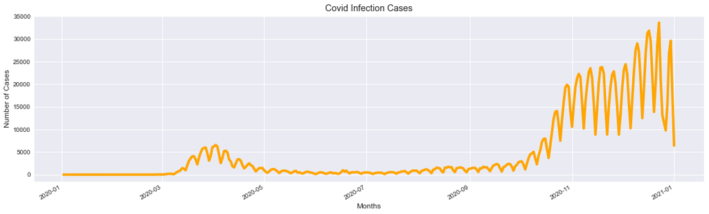

```python
#plotting the covid cases according to the month

daily_cases = df_covid.groupby("date").sum()


sns.set_style("darkgrid")
#sns.color_palette("cool")

plt.figure(figsize=(16,5))
plt.title("Covid Infection Cases")
sns.lineplot(data = daily_cases["cases"], color = "orange")
plt.ylabel("Number of Cases")
plt.xlabel("Months")

plt.style.use("fivethirtyeight")

plt.gcf().autofmt_xdate()
plt.tight_layout()
plt.show()
```

## From the lineplot of covid_cases we can say that, infection rate were almost 0 between January to March. Between March and May the number of infected people increases compare to the first 3 months. After that, till October the amount of cases were under control before significantly increasing during the period of November to January. This period is called the second wave of Covid.

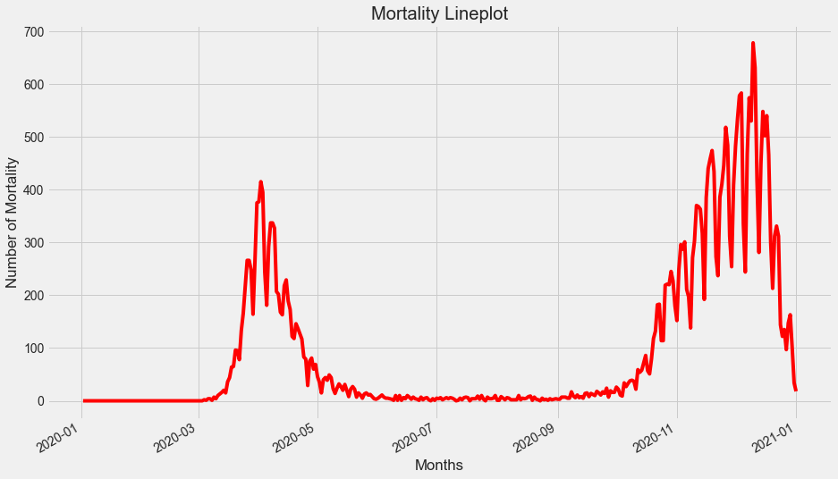

```python
#daily mortality

plt.figure(figsize=(14,9))
plt.title("Mortality Lineplot")
sns.lineplot(data = daily_cases["deaths"], color = "red")
plt.ylabel("Number of Mortality")
plt.xlabel("Months")
plt.gcf().autofmt_xdate()
plt.show()
```

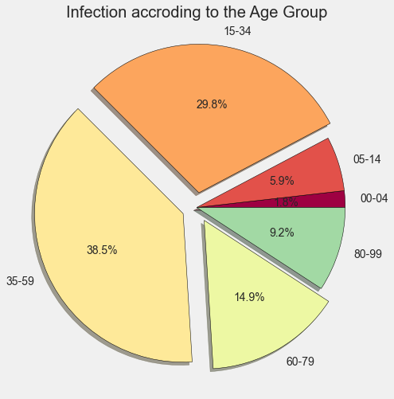

```python
#which age groups are most affected by the virus

plt.style.use("fivethirtyeight")
plt.tight_layout()

by_age = df_covid.groupby("age_group").sum()
by_age.sort_values("cases",ascending = False)

cmap = plt.get_cmap("Spectral")
colors = [cmap(i) for i in np.linspace(0, 1, 8)]
explode = [0,0,0.1,0.1,0.1,0]

plt.figure(figsize = (10,8))
plt.title("Infection accroding to the Age Group")
cases_pie = plt.pie(by_age.cases, labels = by_age.index, autopct = "%1.1f%%",shadow = True , colors = colors
                   ,wedgeprops={'edgecolor':'black'},explode = explode)
```

## From the pie chart we can tell that people of age group of 35-59 are the most infected age group. But covid was not nice to the elderly and younger age groups.

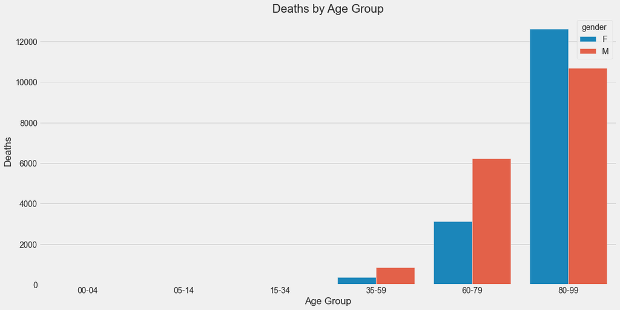

```python
#How the number of deaths is distributed over different age groups of both genders

covid = df_covid.groupby(['age_group','gender'], as_index = False).sum()

plt.figure(figsize=(16,8))
sns.barplot(y = covid.deaths, x = covid.age_group, hue = covid.gender, data = covid)

plt.style.use("fivethirtyeight")


plt.title('Deaths by Age Group')
plt.xlabel('Age Group')
plt.ylabel('Deaths')
```

## This barplot indicates that females in the 80-99 age group died more by the virus than males. The ratio is half and totally opposite in the age group of 60-79.

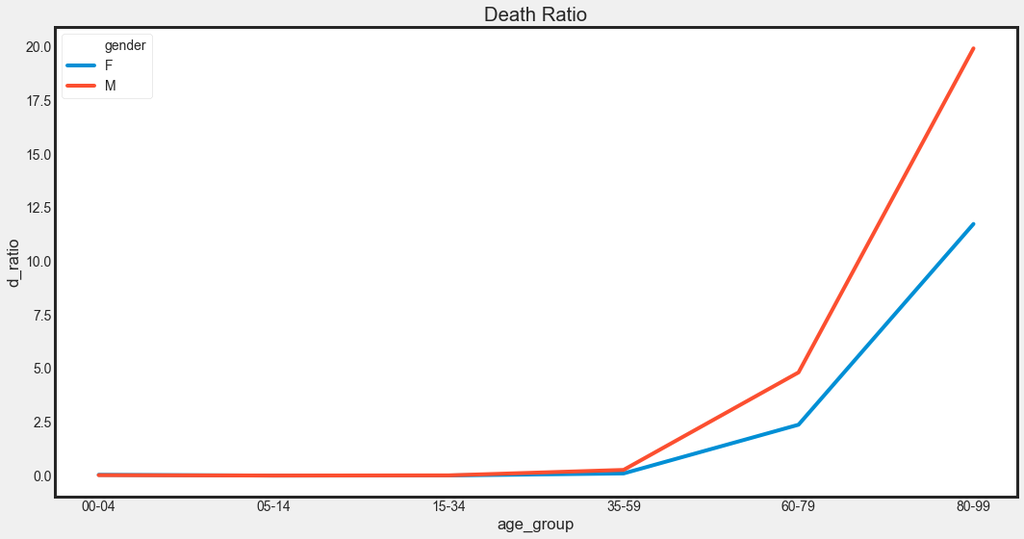

```python
#death ratio by gender

gender = df_covid.groupby(by=["age_group","gender"]).sum().reset_index()
gender["d_ratio"] = 100 * gender["deaths"] / gender["cases"]

plt.figure(figsize=(15,8))
sns.set_style("ticks")
sns.lineplot(data = gender,x="age_group",y="d_ratio",hue = "gender")
plt.title("Death Ratio")

plt.tight_layout()
plt.show()
```

# This lineplot illustrates that death ratio is higher in elderly male age-group compare to female age groups.

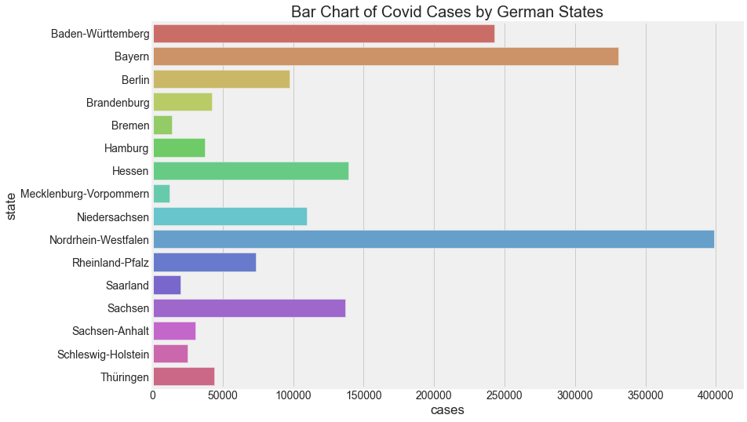

```python
#states comparison

by_state = df_covid.groupby("state").sum()
by_state.sort_values("cases",ascending = True)
#width = 0.25

plt.figure(figsize=(12,8))
plt.style.use("fivethirtyeight")
plt.tight_layout()

plt.title("Bar Chart of Covid Cases by German States")
#plt.xlabel("Number of Total Cases")
#plt.ylabel("Name of State")
sns.barplot(by_state.cases, by_state.index, palette= 'hls')
#plt.legend()
plt.show()
```

```python
df_mp.head()
```

|  | ADE | RS | RS_0 | GEN | geometry |
| --- | --- | --- | --- | --- | --- |
| 0 | 2 | 02 | 020000000000 | Hamburg | MULTIPOLYGON (((3578695.661 5955304.456, 35781... |
| 1 | 2 | 03 | 030000000000 | Niedersachsen | MULTIPOLYGON (((3354775.046 5942939.764, 33546... |
| 2 | 2 | 04 | 040000000000 | Bremen | MULTIPOLYGON (((3468658.496 5898364.974, 34702... |
| 3 | 2 | 05 | 050000000000 | Nordrhein-Westfalen | POLYGON ((3477450.781 5820982.368, 3479895.578... |
| 4 | 2 | 06 | 060000000000 | Hessen | POLYGON ((3535084.230 5721608.644, 3535279.888... |

```python
#dropping unnecessary columns from dataset

df_mp = df_mp.drop(columns = ["ADE", "RS" ,"RS_0"])
```

```python
df_mp.head()
```

|  | GEN | geometry |
| --- | --- | --- |
| 0 | Hamburg | MULTIPOLYGON (((3578695.661 5955304.456, 35781... |
| 1 | Niedersachsen | MULTIPOLYGON (((3354775.046 5942939.764, 33546... |
| 2 | Bremen | MULTIPOLYGON (((3468658.496 5898364.974, 34702... |
| 3 | Nordrhein-Westfalen | POLYGON ((3477450.781 5820982.368, 3479895.578... |
| 4 | Hessen | POLYGON ((3535084.230 5721608.644, 3535279.888... |

```python
state_covid = df_covid.groupby(by = 'state',as_index=False).sum()
state_demo = df_dmo[['state','population']].groupby(by='state',as_index = False).sum()
df_state = df_mp.merge(state_covid, how = "left", left_on = "GEN", right_on = "state")  #merging 2 dataset together and alligning the columns
df_state = df_state.merge(state_demo, how = "left", left_on = "GEN", right_on = "state")
df_state = df_state.drop(columns = ["state_x", "state_y"]) #dropping state column to avoid multiple same value column existence

df_state["case_ratio"] = df_state["cases"] * (1000 / df_state ["population"])  #getting case ratio per 1000 in a new column
df_state["d_ratio"] = df_state["deaths"] * (1000 / df_state ["population"]) #getting death case ratio per 1000 in a new column
df_state["d_case_ratio"]= 100 * df_state["deaths"] / df_state["cases"]  #getting death-case ratio in a new column

df_state.set_index("GEN", inplace = True)
#state_covid
#state_demo
df_state.head()
```

| GEN | geometry | cases | deaths | recovered | population | case_ratio | d_ratio | d_case_ratio |
| --- | --- | --- | --- | --- | --- | --- | --- | --- |
| Hamburg | MULTIPOLYGON (((3578695.661 5955304.456, 35781... | 37286 | 658 | 27236 | 1841179 | 20.25 | 0.36 | 1.76 |
| Niedersachsen | MULTIPOLYGON (((3354775.046 5942939.764, 33546... | 109797 | 2016 | 92551 | 7982448 | 13.75 | 0.25 | 1.84 |
| Bremen | MULTIPOLYGON (((3468658.496 5898364.974, 34702... | 13700 | 201 | 11380 | 682986 | 20.06 | 0.29 | 1.47 |
| Nordrhein-Westfalen | POLYGON ((3477450.781 5820982.368, 3479895.578... | 398661 | 6701 | 326307 | 17932651 | 22.23 | 0.37 | 1.68 |
| Hessen | POLYGON ((3535084.230 5721608.644, 3535279.888... | 139349 | 2917 | 109223 | 6265809 | 22.24 | 0.47 | 2.09 |

# We have merged 3 different dataset in a single dataset. We have added some new columns in our new dataset. It will help us to visulize our geographical overview.case_ratio, death ratio and death case ratio column will be used in geographical graphs.

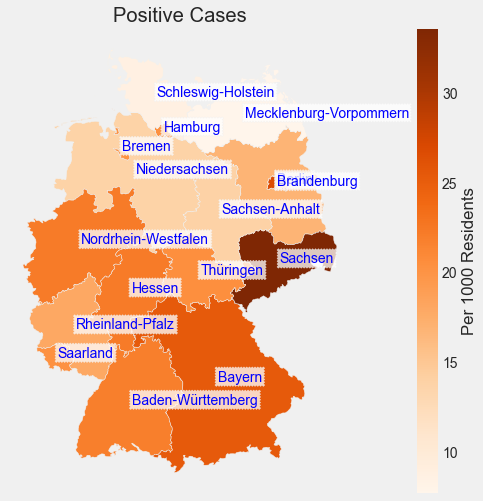

```python
fig, (ax) = plt.subplots(1, figsize=(20,8), edgecolor = 'black')


df_state.plot(column = "case_ratio", legend = True, legend_kwds = {"label": "Per 1000 Residents",
                                                                   "orientation" : "vertical"}, cmap = "Oranges", ax = ax)

for i, geo in df_state.centroid.iteritems():
    ax.annotate(s=i, xy=[geo.x , geo.y], color = "blue", bbox = dict(boxstyle = 'sawtooth, pad =0.2' , fc = 'white', alpha = 0.75))

    ax.set_title("Positive Cases")

ax.axes.get_xaxis().set_visible(False)
ax.axes.get_yaxis().set_visible(False)
```

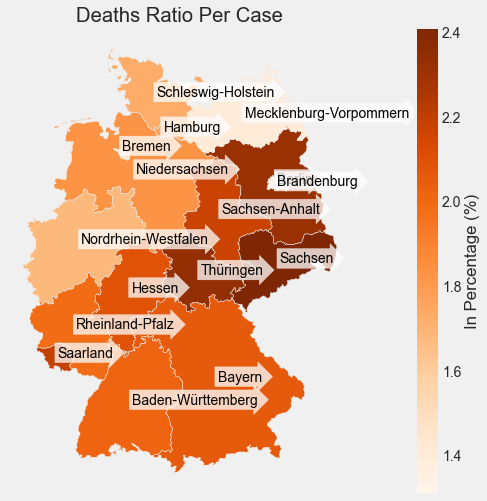

```python
fig, (ax1) = plt.subplots(1, figsize=(20,8), edgecolor = 'black')

df_state.plot(column="d_case_ratio",legend = True, legend_kwds={"label": "In Percentage (%)",
                                                                   "orientation": "vertical"}, cmap = "Oranges", ax = ax1)

for i, geo in df_state.centroid.iteritems():
     ax1.annotate(s=i, xy=[geo.x, geo.y], color = "black", bbox = dict(boxstyle = 'rarrow, pad =0.2', fc = 'white', alpha = 0.75))
ax1.set_title("Deaths Ratio Per Case")

ax1.axes.get_xaxis().set_visible(False)
ax1.axes.get_yaxis().set_visible(False)

plt.show()
```

# Using the geomatric value of our dataset we have tried to visualize all the states of Germany according to Positive cases and Death ratio per case. They have been calculated above. Because of using multiple dataset for displaying our geomatric data there might be a sligh change between state comparison bar graph and geo graph. The data displayed above might seem diverse.